# Part II - Ford-GoBike-System-Data

## by Sashya Baral

## Investigation Overview

> In this presentation, I am analyzing the gender data of the bike users in depth. I am analyzing the relationship between gender and other corresponding variables such as average duration time, birth year, start day of biking, and time of day gone biking.

## Dataset Overview

> The dataset is from the Ford GoBike System Data from the city of San Fransico. It contains 172535 entries. I have used a CSV from Part I that was cleaned.

## Proportion of the Genders in the Ford-GoBike-System-Data

> I am analyzing the gender proportion of the Bike riders in the Ford-GoBike-System-Data. I am interested in seeing the percentage of all the genders.

> From this data, we can see that the majority of Bikers in the the Ford-GoBike-System-Data are males. They make up about 75% of the bike riders. Females make up around 23.4% of bike riders, and the rest are the other gender at 2.1%.

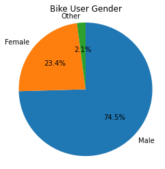

## Average Biking Duration Based on Gender

> I want to find the average biking duration (in minutes) based on the user's genders.

> From this data, we can see that the other gender bike users had the highest average of around 11.89 minutes, females came in second with an average of around 11.5 minutes, and males came in last with an average of around 10.19 minutes

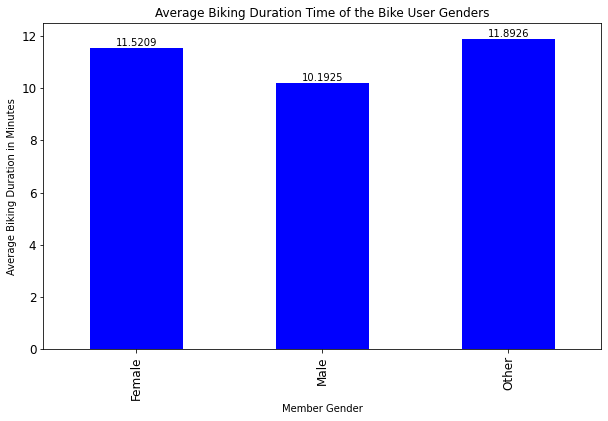

## Average biking trip duration for the different genders during the days of the week

> I want to find the average biking trip duration for all the genders for the days of the week.

> On all days of the week except for Monday, the average trip duration was the highest for the other gender, then the average duration was second highest for females, and men came in last. On Monday, females had the highest average duration time, then the other gender, and males were last in average duration time for biking. For all days of the week, the other gender had the highest standard deviations, then females had the second highest standard deviation, and men had the least standard deviation.

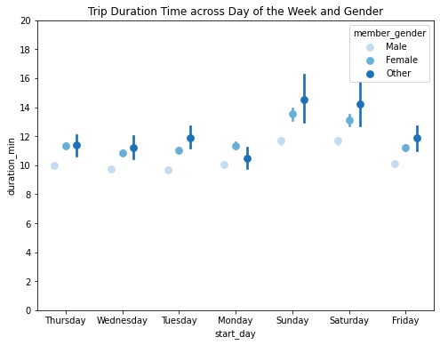